# OPEB analysis

November 29, 2021

# 1 Marc Joffe’s OPEB data

## 1.1 Large California, Nevada, and Oregon school districts in 2019: pensions and OPEB as % of revenue

SFUSD has 7th highest OPEB liability as % of total revenue, among large school districts in California, Nevada, and Oregon (defined as those that have at least $100 million in revenue).

|  | stabbr | name | pension_debt | opeb_debt | total_revenues | penrev | opebrev |
| --- | --- | --- | --- | --- | --- | --- | --- |
| 1 | CA | Los Angeles Unified School District | 6996258000 | 11180799000 | 9204778000 | 0.760068086378618 | 1.21467340114015 |
| 2 | NV | Elko County School District | 118223667 | 123550558 | 138642371 | 0.852723926655871 | 0.891145737835081 |
| 3 | CA | Fresno Unified School District | 906727000 | 1019255291 | 1170411431 | 0.774707915510781 | 0.870852132851392 |
| 4 | CA | Sacramento City Unified School District | 497997000 | 526175712 | 696512501 | 0.714986449324332 | 0.755443314003061 |
| 5 | CA | Chaffey Joint Union High School District | 292040588 | 248983672 | 355666338 | 0.821108316413121 | 0.700048459463712 |
| 6 | CA | Oxnard Union High School District | 193868729 | 171204475 | 263761828 | 0.73501435165971 | 0.649087384244243 |
| 7 | CA | San Francisco Unified School District | 780676405 | 756461071 | 1211791348 | 0.644233354437187 | 0.624250265731391 |
| 8 | CA | Clovis Unified School District | 468127821 | 359502162 | 613744427 | 0.762740646441748 | 0.585752222235657 |
| 9 | CA | Alhambra Unified School District | 218866320 | 151338224 | 310587069 | 0.70468587344826 | 0.487265050947759 |
| 10 | CA | Palmdale School District | 232312556 | 166981455 | 360358698 | 0.644670316796405 | 0.463375675200158 |

[output cut: 245 more lines]

# 2 SACS financial data

## 2.1 SFUSD Health, pension, and OPEB benefits as % of general fund

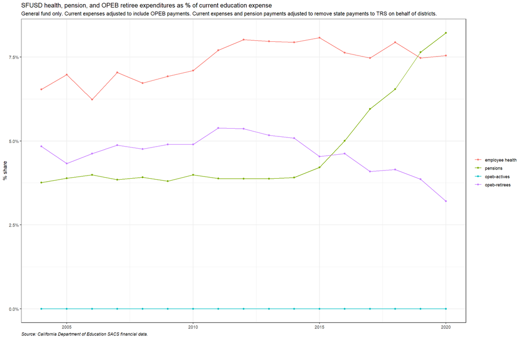

## 2.2 SFUSD real per-pupil current educational spending on benefits and other items

### 2.2.1 Plot over time

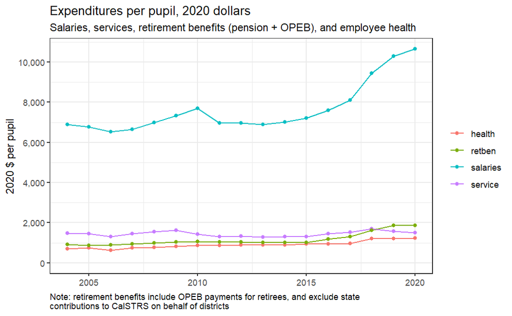

### 2.2.2 Table of real per pupil general fund spending at key points in time

Real per-pupil general fund expenditures in SFUSD

2020 dollars (GDP price index)

| name | y2005 | y2010 | y2015 | y2020 | change | pchange |
| --- | --- | --- | --- | --- | --- | --- |
| currentadj | 10,698 | 12,082 | 11,712 | 16,343 | 4,631 | 28.3% |
| salaries | 6,764 | 7,687 | 7,208 | 10,651 | 3,443 | 32.3% |
| ercpenadj | 416 | 482 | 493 | 1,344 | 851 | 63.3% |
| health | 746 | 858 | 946 | 1,233 | 287 | 23.2% |
| gfopeb | 463 | 592 | 531 | 524 | −7 | −1.3% |
| books | 456 | 438 | 614 | 501 | −113 | −22.7% |
| other | 1,852 | 2,026 | 1,919 | 2,091 | 171 | 8.2% |

## 2.3 General fund OPEB spending

A few quick exploratory graphs

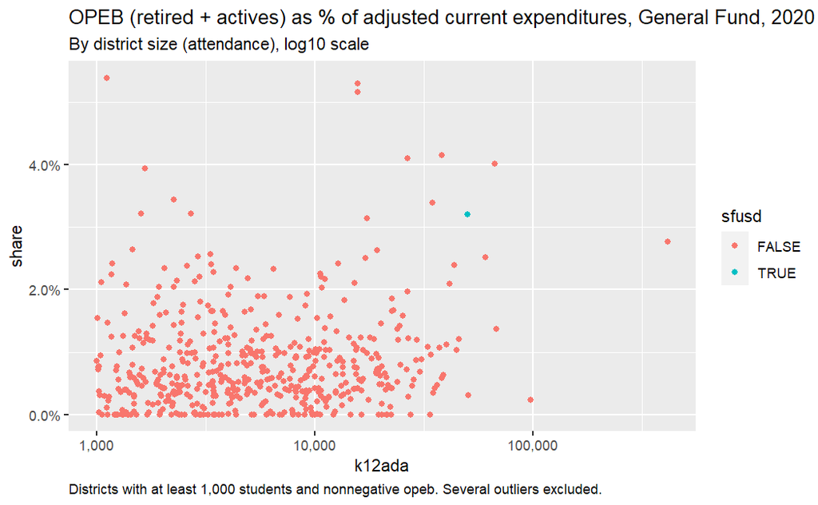

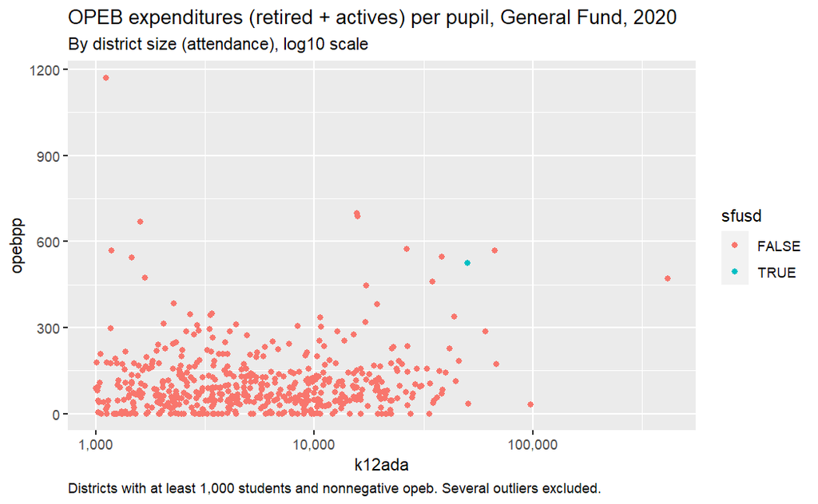

## 2.4 General fund OPEB spending by largest districts (by attendance)

### 2.4.1 Actives and retired

#### 2.4.1.1 SFUSD over time

We don’t bother with this because the data show no spending on actives in any year by SFUSD.

This is a bit mysterious as we might have thought the $25 million payment in FY 2020 would be treated as prefunding for actives. But the relevant SACS codes are all zero.

#### 2.4.1.2 Largest districts (by attendance)

General fund opeb-related expenditures, 2020, largest districts by enrollment

GF expenditures in $ millions, per pupil in $

| ccode | dcode | dname | k12ada | gfopebretired | gfopebactives | gfopeb | opebpp |
| --- | --- | --- | --- | --- | --- | --- | --- |
| 19 | 64733 | Los Angeles Unified | 413,606 | 0.10 | 194.01 | 194.10 | 469 |
| 37 | 68338 | San Diego Unified | 97,479 | 2.99 | 0.00 | 2.99 | 31 |
| 19 | 64725 | Long Beach Unified | 68,159 | 0.51 | 11.18 | 11.69 | 171 |
| 10 | 62166 | Fresno Unified | 66,904 | 38.01 | 0.00 | 38.01 | 568 |
| 34 | 67314 | Elk Grove Unified | 60,769 | 1.75 | 15.58 | 17.33 | 285 |
| 33 | 67033 | Corona-Norco Unified | 50,642 | 1.70 | 0.00 | 1.70 | 34 |
| 38 | 68478 | San Francisco Unified | 50,096 | 26.27 | 0.00 | 26.27 | 524 |
| 36 | 67876 | San Bernardino City Unified | 45,869 | 3.74 | 4.66 | 8.40 | 183 |
| 30 | 66464 | Capistrano Unified | 44,603 | 5.05 | 0.00 | 5.05 | 113 |
| 30 | 66670 | Santa Ana Unified | 43,665 | 0.00 | 14.77 | 14.77 | 338 |

### 2.4.2 Teachers and classified

#### 2.4.2.1 SFUSD over time

This is important because if we see that trends for teachers and classified are similar, we will feel better about drawing conclusions based on J-90 data, which are for teachers (certificated employees) only.

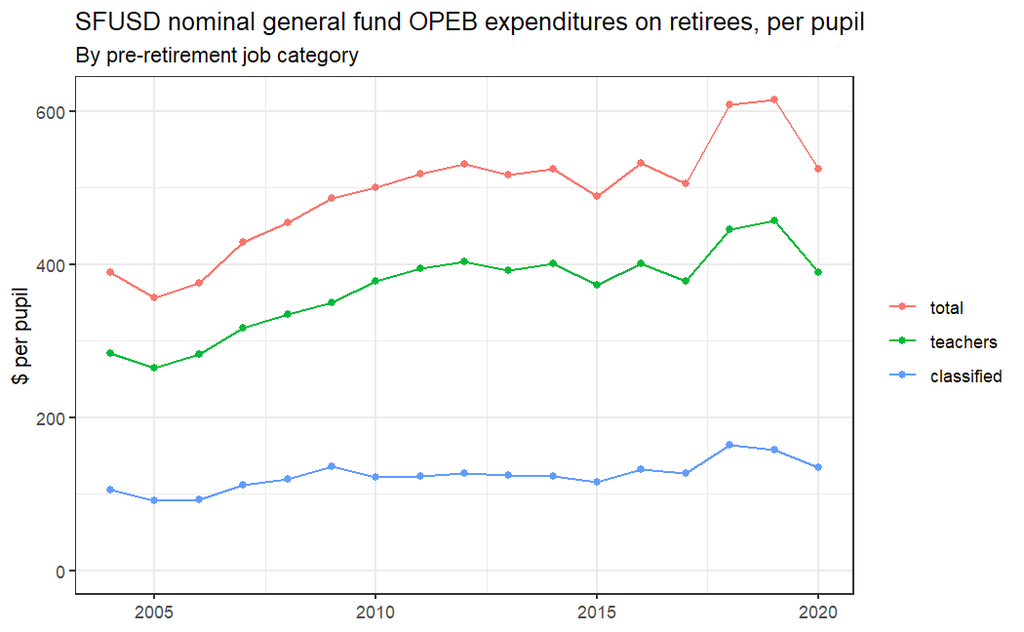

### 2.4.3 California large districts’ general fund OPEB spending over time

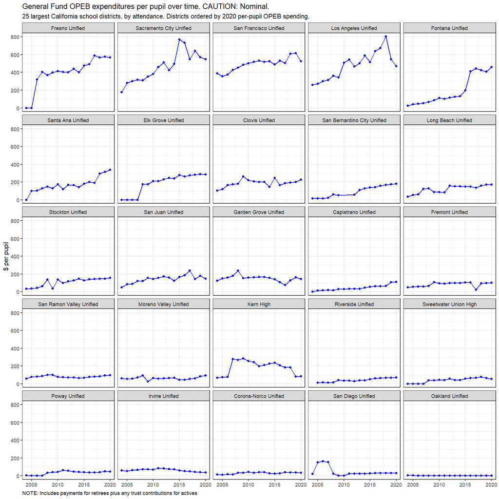

### 2.4.4 Bay Area large districts’ general fund OPEB spending over time

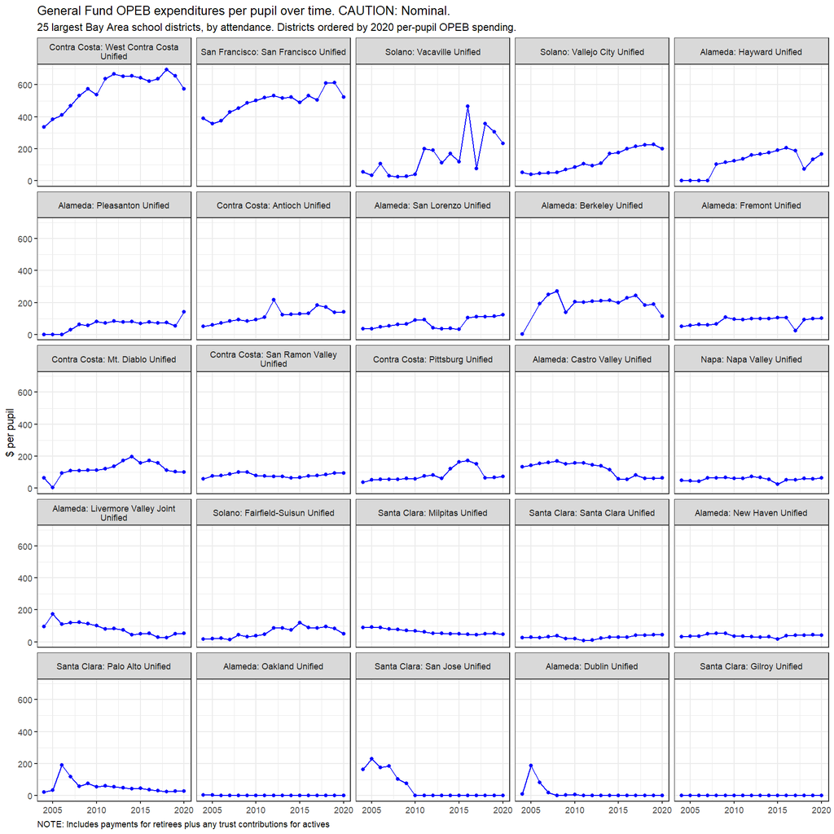

# 3 J-90 OPEB data

## 3.1 Districts that provide benefits for age 66+ retirees

Districts that provide OPEB health benefits beyond age 65

ONLY includes districts that provide OPEB health benefits

| year | no | yes | total | pctyes |
| --- | --- | --- | --- | --- |
| 2016 | 481 | 95 | 576 | 16.5% |
| 2017 | 499 | 91 | 590 | 15.4% |
| 2018 | 485 | 91 | 576 | 15.8% |
| 2019 | 489 | 88 | 577 | 15.3% |
| 2020 | 441 | 79 | 520 | 15.2% |

Source: J-90 data

## 3.2 SFUSD by plan type - cost and ftes

SFUSD estimated OPEB FTEs and costs, plan year 2020

Source: J-90 data

| plantype | Number of plans | # of OPEB FTEs (i.e., retirees) min | # of OPEB FTEs (i.e., retirees) max | # of OPEB FTEs (i.e., retirees) total | $ millions Total employee cost<sup>1</sup> | $ millions Total employer cost<sup>1</sup> | $ millions Total cost<sup>1</sup> | Employer share |  |
| --- | --- | --- | --- | --- | --- | --- | --- | --- | --- |
| health | 25 | 1 | 1,806 | 5,038 | 5.47 | 36.00 | 41.47 |  | 86.8% |
| dental | 15 | 1 | 2,128 | 3,437 | 2.35 | 0.00 | 2.35 | 0.0% |  |
| vision | 6 | 1 | 448 | 666 | 0.09 | 0.00 | 0.09 | 0.0% |  |
| Totals/min/max | 46 | 1 | 2,128 | 5,038 | 0.00 | 0.00 | 0.00 | 82.0% |  |

<sup>*1*</sup> CAUTION: cost estimates based on J-90 are overestimates but employer share is plausible.

# 4 OPEB by age

[output not shown]

[output cut: 15 more lines]

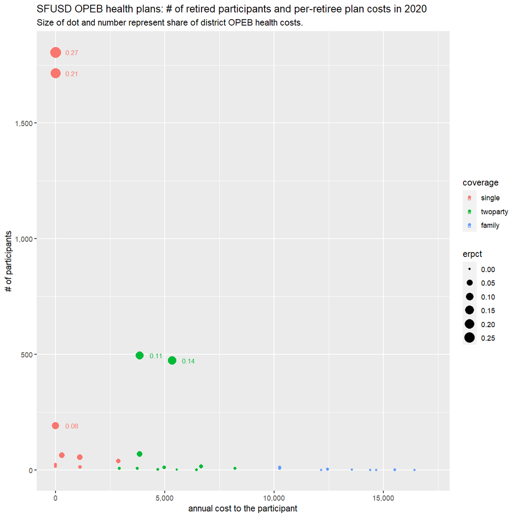